YELP NEW ORLEANS / GEOGRAPHIC ANALYSIS

# Restaurants with good ratings and a minimum ground elevation

Cajun/Creole, Cafes, and Arts & Entertainment, connected through Yelp restaurant labels. Ground elevation at or above the category-group 10th percentile; Yelp business stars at least 4.

**618**Restaurants in the category group

**344**Meet both thresholds

**-0.60 m**10th-percentile elevation cutoff

**40**Neighborhoods with qualifying restaurants

**10th percentile means a lower cutoff.** It retains roughly 90% of restaurants by elevation before applying the rating filter. It does not select the highest-elevation 10%. Negative elevations can qualify when the cutoff is negative.

## Category inclusion and overlap

A business must have the exact `Restaurants` label and match **at least one** of the three selected labels. A business matching multiple labels is counted once in the combined group. Arts & Entertainment describes an experience rather than a cuisine; the overlap counts below make that distinction visible.

Search this table

| category | category_restaurants | qualifying_restaurants |
| --- | --- | --- |
| arts & entertainment | 86 | 54 |
| cafes | 173 | 110 |
| cajun/creole | 402 | 204 |

Search this table

| category_1 | category_2 | restaurants_with_both |
| --- | --- | --- |
| cajun/creole | cafes | 16 |
| cajun/creole | arts & entertainment | 21 |
| cafes | arts & entertainment | 7 |

## Compare the geographic systems

Counts refer to distinct restaurants. Average stars and median ground elevation describe only restaurants meeting both thresholds. Average stars gives each restaurant equal weight. Yelp review counts are summed as a volume indicator; they are not reviewer-adjusted ratings.

Search this table

| geographic_system | total_areas | areas_with_category_restaurants | areas_with_qualifying_restaurants | category_restaurants_assigned | category_restaurants_unmatched | qualifying_restaurants_assigned | qualifying_restaurants_unmatched | smallest_occupied_area_count | largest_area_count | qualifying_areas_below_5_restaurants |
| --- | --- | --- | --- | --- | --- | --- | --- | --- | --- | --- |
| Neighborhood Statistical Area | 72 | 52 | 40 | 611 | 7 | 341 | 3 | 1 | 162 | 25 |
| Census tract (2024) | 184 | 102 | 69 | 611 | 7 | 341 | 3 | 1 | 113 | 54 |

### Neighborhood Statistical Areas

Search this table

| Area | Selected | Qualifying | Percent | Average_stars | Median_ground_m | Yelp_review_count |
| --- | --- | --- | --- | --- | --- | --- |
| FRENCH QUARTER | 162 | 85 | 52.47 | 4.14 | 1.57 | 67539 |
| CENTRAL BUSINESS DISTRICT | 116 | 58 | 50.00 | 4.16 | 0.76 | 41416 |
| MARIGNY | 30 | 22 | 73.33 | 4.09 | 1.47 | 6601 |
| LOWER GARDEN DISTRICT | 35 | 21 | 60.00 | 4.26 | 1.55 | 13860 |
| CENTRAL CITY | 27 | 19 | 70.37 | 4.32 | 0.92 | 3820 |
| BYWATER | 13 | 13 | 100.00 | 4.19 | 1.22 | 2072 |
| LEONIDAS | 15 | 12 | 80.00 | 4.50 | 1.23 | 4588 |
| TREME - LAFITTE | 14 | 10 | 71.43 | 4.45 | 0.19 | 1023 |
| EAST RIVERSIDE | 12 | 9 | 75.00 | 4.33 | 1.75 | 4227 |
| UPTOWN | 9 | 7 | 77.78 | 4.43 | 0.94 | 1013 |
| WEST RIVERSIDE | 7 | 7 | 100.00 | 4.36 | 2.00 | 1235 |
| FRERET | 6 | 5 | 83.33 | 4.30 | -0.24 | 559 |
| MID-CITY | 28 | 5 | 17.86 | 4.20 | -0.22 | 554 |
| CITY PARK | 6 | 5 | 83.33 | 4.10 | -0.19 | 1006 |
| IRISH CHANNEL | 6 | 5 | 83.33 | 4.00 | 1.62 | 1919 |
| FAIRGROUNDS | 10 | 4 | 40.00 | 4.50 | 0.15 | 985 |
| SEVENTH WARD | 6 | 4 | 66.67 | 4.50 | 0.12 | 1215 |
| ST. CLAUDE | 5 | 4 | 80.00 | 4.50 | 0.29 | 128 |
| AUDUBON | 7 | 4 | 57.14 | 4.25 | 2.18 | 580 |
| ST. ROCH | 7 | 4 | 57.14 | 4.25 | 0.69 | 207 |
| TOURO | 5 | 4 | 80.00 | 4.25 | 0.76 | 2289 |
| GERT TOWN | 4 | 4 | 100.00 | 4.00 | -0.27 | 443 |
| MILAN | 5 | 3 | 60.00 | 4.67 | -0.56 | 122 |
| GARDEN DISTRICT | 6 | 3 | 50.00 | 4.50 | 1.04 | 5369 |
| EAST CARROLLTON | 6 | 3 | 50.00 | 4.33 | 1.21 | 142 |
| Unmatched | 7 | 3 | 42.86 | 4.17 | 0.57 | 482 |
| McDONOGH | 2 | 2 | 100.00 | 4.75 | 1.01 | 11 |
| OLD AURORA | 3 | 2 | 66.67 | 4.75 | 0.77 | 45 |
| ALGIERS POINT | 3 | 2 | 66.67 | 4.25 | 1.82 | 95 |
| MARLYVILLE - FONTAINEBLEAU | 2 | 2 | 100.00 | 4.25 | -0.10 | 257 |
| TULANE - GRAVIER | 6 | 2 | 33.33 | 4.25 | -0.26 | 97 |
| LITTLE WOODS | 5 | 2 | 40.00 | 4.00 | 1.47 | 122 |
| BAYOU ST. JOHN | 1 | 1 | 100.00 | 4.50 | -0.02 | 30 |
| BEHRMAN | 2 | 1 | 50.00 | 4.50 | 0.83 | 9 |
| HOLY CROSS | 1 | 1 | 100.00 | 4.50 | 0.79 | 153 |
| IBERVILLE | 1 | 1 | 100.00 | 4.50 | 0.04 | 218 |
| LAKESHORE - LAKE VISTA | 4 | 1 | 25.00 | 4.50 | 0.92 | 20 |
| LOWER NINTH WARD | 1 | 1 | 100.00 | 4.50 | -0.55 | 23 |
| GENTILLY TERRACE | 4 | 1 | 25.00 | 4.00 | -0.33 | 22 |
| LAKE TERRACE & OAKS | 2 | 1 | 50.00 | 4.00 | 0.18 | 5 |
| ST. THOMAS DEV | 1 | 1 | 100.00 | 4.00 | 2.12 | 18 |
| B. W. COOPER | 0 | 0 |  |  |  | 0 |
| BLACK PEARL | 0 | 0 |  |  |  | 0 |
| BROADMOOR | 3 | 0 | 0.00 |  |  | 0 |
| DESIRE AREA | 2 | 0 | 0.00 |  |  | 0 |
| DILLARD | 0 | 0 |  |  |  | 0 |
| DIXON | 0 | 0 |  |  |  | 0 |
| FILMORE | 0 | 0 |  |  |  | 0 |
| FISCHER DEV | 0 | 0 |  |  |  | 0 |
| FLORIDA AREA | 0 | 0 |  |  |  | 0 |
| FLORIDA DEV | 0 | 0 |  |  |  | 0 |
| GENTILLY WOODS | 0 | 0 |  |  |  | 0 |
| HOLLYGROVE | 0 | 0 |  |  |  | 0 |
| LAKE CATHERINE | 0 | 0 |  |  |  | 0 |
| LAKEVIEW | 5 | 0 | 0.00 |  |  | 0 |
| LAKEWOOD | 0 | 0 |  |  |  | 0 |
| MILNEBURG | 1 | 0 | 0.00 |  |  | 0 |
| NAVARRE | 1 | 0 | 0.00 |  |  | 0 |
| NEW AURORA - ENGLISH TURN | 1 | 0 | 0.00 |  |  | 0 |
| PINES VILLAGE | 1 | 0 | 0.00 |  |  | 0 |
| PLUM ORCHARD | 0 | 0 |  |  |  | 0 |
| PONTCHARTRAIN PARK | 2 | 0 | 0.00 |  |  | 0 |
| READ BLVD EAST | 5 | 0 | 0.00 |  |  | 0 |
| READ BLVD WEST | 0 | 0 |  |  |  | 0 |
| ST. ANTHONY | 0 | 0 |  |  |  | 0 |
| ST. BERNARD AREA | 0 | 0 |  |  |  | 0 |
| TALL TIMBERS - BRECHTEL | 1 | 0 | 0.00 |  |  | 0 |
| U.S. NAVAL BASE | 0 | 0 |  |  |  | 0 |
| VIAVANT - VENETIAN ISLES | 2 | 0 | 0.00 |  |  | 0 |
| VILLAGE DE LEST | 0 | 0 |  |  |  | 0 |
| WEST END | 0 | 0 |  |  |  | 0 |
| WEST LAKE FOREST | 2 | 0 | 0.00 |  |  | 0 |
| WHITNEY | 0 | 0 |  |  |  | 0 |

### Census tracts (2024)

Search this table

| Area | Selected | Qualifying | Percent | Average_stars | Median_ground_m | Yelp_review_count |
| --- | --- | --- | --- | --- | --- | --- |
| Tract 134 | 113 | 57 | 50.44 | 4.17 | 0.76 | 40698 |
| Tract 135.02 | 102 | 54 | 52.94 | 4.11 | 1.77 | 57280 |
| Tract 135.01 | 38 | 20 | 52.63 | 4.20 | 0.88 | 8542 |
| Tract 26 | 23 | 16 | 69.57 | 4.09 | 1.56 | 5012 |
| Tract 38 | 25 | 12 | 48.00 | 4.12 | 2.35 | 2435 |
| Tract 129 | 13 | 11 | 84.62 | 4.45 | 1.35 | 4577 |
| Tract 77 | 19 | 11 | 57.89 | 4.27 | 2.25 | 8440 |
| Tract 139 | 12 | 10 | 83.33 | 4.40 | 0.89 | 2267 |
| Tract 12 | 10 | 10 | 100.00 | 4.15 | 1.32 | 1724 |
| Tract 39 | 9 | 8 | 88.89 | 4.44 | 0.03 | 950 |
| Tract 82 | 12 | 7 | 58.33 | 4.14 | 1.43 | 3231 |
| Tract 97 | 7 | 6 | 85.71 | 4.42 | 1.83 | 997 |
| Tract 18 | 7 | 6 | 85.71 | 4.08 | 0.97 | 1589 |
| Tract 111 | 6 | 5 | 83.33 | 4.30 | -0.24 | 559 |
| Tract 84 | 7 | 5 | 71.43 | 4.10 | 1.00 | 808 |
| Tract 37.02 | 10 | 4 | 40.00 | 4.50 | 0.15 | 985 |
| Tract 109 | 5 | 4 | 80.00 | 4.25 | 0.46 | 590 |
| Tract 144 | 4 | 4 | 100.00 | 4.25 | 2.10 | 775 |
| Tract 19 | 6 | 4 | 66.67 | 4.25 | 0.69 | 207 |
| Tract 99 | 5 | 4 | 80.00 | 4.25 | 0.76 | 2289 |
| Tract 54 | 7 | 4 | 57.14 | 4.12 | -0.15 | 466 |
| Tract 107 | 4 | 3 | 75.00 | 4.67 | 1.22 | 423 |
| Tract 78 | 3 | 3 | 100.00 | 4.50 | 1.26 | 2189 |
| Tract 90 | 6 | 3 | 50.00 | 4.50 | 1.04 | 5369 |
| Tract 11 | 3 | 3 | 100.00 | 4.33 | 1.05 | 348 |
| Tract 126 | 5 | 3 | 60.00 | 4.33 | 1.21 | 142 |
| Tract 96 | 5 | 3 | 60.00 | 4.17 | 1.71 | 3230 |
| Tract 9800 | 4 | 3 | 75.00 | 4.17 | -0.37 | 106 |
| Unmatched | 7 | 3 | 42.86 | 4.17 | 0.57 | 482 |
| Tract 142 | 4 | 3 | 75.00 | 4.00 | 1.62 | 754 |

[output cut: 155 more lines]

All boundary areas are included, even when Selected and Qualifying are zero. Percent is the share of selected-category restaurants in that area that qualify. Any unmatched restaurants are shown separately rather than reassigned to a nearby polygon.

## Where the qualifying restaurants are

Hover a polygon to see its area name and statistics, or a dot for restaurant details. The downloadable PNG versions are saved alongside this report.

### Neighborhood Statistical Areas

[figure not shown]

### Census tracts (2024)

[figure not shown]

Use neighborhoods to communicate recognizable destinations and census tracts to inspect smaller spatial patterns. Areas with only a few qualifying restaurants provide limited evidence for an area-wide recommendation. Maps show restaurant concentrations, not restaurant density per square kilometer.

**Main-analysis choice: neighborhoods.** They provide recognizable area names and group restaurants into fewer sparse comparisons. Of the 40 occupied neighborhoods, 25 have fewer than five qualifying restaurants; the tract comparison has 54 such areas among 69 occupied tracts. Small groups still need careful interpretation.

## Top 10 qualifying restaurants

Ranking rule: stars descending, review count descending, then ground elevation descending. Business ID resolves remaining ties. There is no additional minimum review-count requirement.

Search this table

| Rank | Restaurant | Stars | Reviews | Ground_m | Ground_ft | Neighborhood | Census_tract | Categories | Address | Open_in_Yelp_snapshot |
| --- | --- | --- | --- | --- | --- | --- | --- | --- | --- | --- |
| 1 | Cafe Porche and snowbar | 5 | 172 | 0.83 | 2.71 | CENTRAL CITY | Tract 139 | cafes; cajun/creole | 1625 Baronne St | Yes |
| 2 | Luna Libre | 5 | 50 | 0.27 | 0.89 | ST. CLAUDE | Tract 136 | arts & entertainment | 3600 St Claude Ave | Yes |
| 3 | Sorella5 | 5 | 49 | 0.68 | 2.23 | CENTRAL BUSINESS DISTRICT | Tract 134 | cajun/creole | 616 Baronne St | Yes |
| 4 | Park Island Brew | 5 | 48 | 0.19 | 0.63 | FAIRGROUNDS | Tract 37.02 | cafes | 1686 Gentilly Blvd | Yes |
| 5 | Iacovone Kitchen | 5 | 38 | -0.19 | -0.63 | FRERET | Tract 111 | cafes | 5033 Freret St | Yes |
| 6 | P's and Q's | 5 | 25 | 2.00 | 6.57 | WEST RIVERSIDE | Tract 114 | cafes | 5720 Magazine St | No |
| 7 | Nonno’s Cajun Cuisine and Pastries | 5 | 24 | 0.19 | 0.64 | SEVENTH WARD | Tract 29 | cajun/creole | 2025 N Claiborne Ave | Yes |
| 8 | Undergrowth Coffee | 5 | 20 | 2.04 | 6.70 | EAST RIVERSIDE | Tract 97 | cafes | 4332 Magazine St | Yes |
| 9 | The Neutral Ground Bar & Grill | 5 | 18 | 0.83 | 2.72 | CENTRAL CITY | Tract 139 | arts & entertainment; cajun/creole | 1638 Clio St | No |
| 10 | Mr B's Bakery | 5 | 18 | 0.82 | 2.69 | OLD AURORA | Tract 6.06 | cajun/creole | 4801 General Meyer Ave, Ste 107 | Yes |

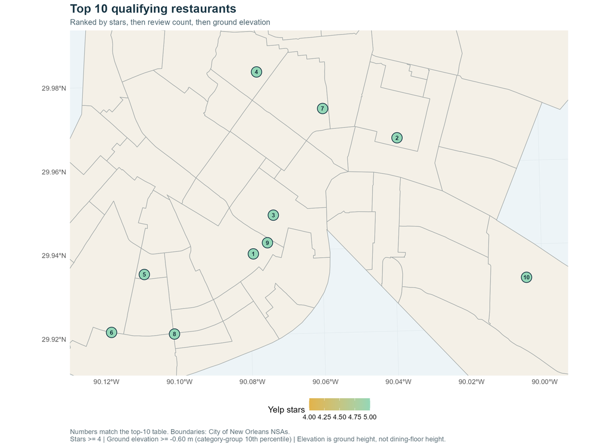

## How the filters affect the category group

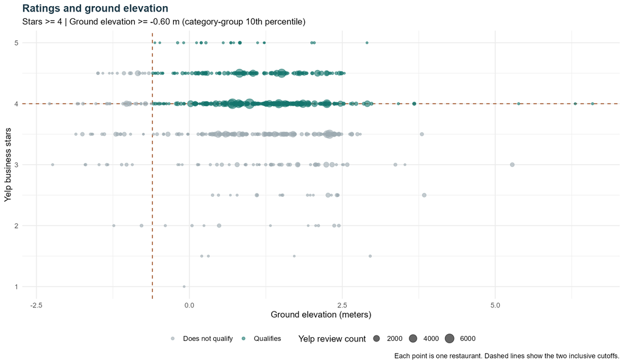

## All qualifying restaurants

Search this table

| Rank | Restaurant | Stars | Reviews | Ground_m | Ground_ft | Neighborhood | Census_tract | Categories | Address | Open_in_Yelp_snapshot |
| --- | --- | --- | --- | --- | --- | --- | --- | --- | --- | --- |
| 1 | Cafe Porche and snowbar | 5.0 | 172 | 0.83 | 2.71 | CENTRAL CITY | Tract 139 | cafes; cajun/creole | 1625 Baronne St | Yes |
| 2 | Luna Libre | 5.0 | 50 | 0.27 | 0.89 | ST. CLAUDE | Tract 136 | arts & entertainment | 3600 St Claude Ave | Yes |
| 3 | Sorella5 | 5.0 | 49 | 0.68 | 2.23 | CENTRAL BUSINESS DISTRICT | Tract 134 | cajun/creole | 616 Baronne St | Yes |
| 4 | Park Island Brew | 5.0 | 48 | 0.19 | 0.63 | FAIRGROUNDS | Tract 37.02 | cafes | 1686 Gentilly Blvd | Yes |
| 5 | Iacovone Kitchen | 5.0 | 38 | -0.19 | -0.63 | FRERET | Tract 111 | cafes | 5033 Freret St | Yes |
| 6 | P's and Q's | 5.0 | 25 | 2.00 | 6.57 | WEST RIVERSIDE | Tract 114 | cafes | 5720 Magazine St | No |
| 7 | Nonno’s Cajun Cuisine and Pastries | 5.0 | 24 | 0.19 | 0.64 | SEVENTH WARD | Tract 29 | cajun/creole | 2025 N Claiborne Ave | Yes |
| 8 | Undergrowth Coffee | 5.0 | 20 | 2.04 | 6.70 | EAST RIVERSIDE | Tract 97 | cafes | 4332 Magazine St | Yes |
| 9 | The Neutral Ground Bar & Grill | 5.0 | 18 | 0.83 | 2.72 | CENTRAL CITY | Tract 139 | arts & entertainment; cajun/creole | 1638 Clio St | No |
| 10 | Mr B's Bakery | 5.0 | 18 | 0.82 | 2.69 | OLD AURORA | Tract 6.06 | cajun/creole | 4801 General Meyer Ave, Ste 107 | Yes |
| 11 | La Vie En Rose Cafe | 5.0 | 11 | 0.55 | 1.82 | CENTRAL CITY | Tract 139 | cajun/creole | 1618 Oretha Castle Haley Blvd | Yes |
| 12 | Stella's Donation Cafe and Coffee Shop | 5.0 | 11 | -0.09 | -0.31 | LEONIDAS | Tract 130 | arts & entertainment | 1923 Leonidas St | No |
| 13 | d4 Tabletop Gaming Cafe | 5.0 | 8 | 1.12 | 3.66 | LEONIDAS | Tract 129 | cafes | 8228 Oak St | Yes |
| 14 | Tacreole Cafe | 5.0 | 8 | 0.12 | 0.39 | CENTRAL BUSINESS DISTRICT | Tract 134 | cajun/creole | 110 S Rampart St | No |
| 15 | Mojo Coffee Roasters | 5.0 | 7 | 2.90 | 9.53 | EAST RIVERSIDE | Tract 97 | cafes | 3983 Tchoupitoulas St | Yes |
| 16 | Prytania Hall Coffee | 5.0 | 6 | 0.68 | 2.22 | TOURO | Tract 99 | cafes | 3445 Prytania St, Ste B | No |
| 17 | Shucks on Teche | 5.0 | 5 | 1.23 | 4.03 | McDONOGH | Tract 2 | cajun/creole | 825 Teche St | Yes |
| 18 | Gulf Coast Crawfish | 5.0 | 5 | 1.22 | 4.01 | UPTOWN | Tract 107 | cajun/creole |  | Yes |
| 19 | Golden Feather Mardi Gras Indian Restaurant Gallery | 5.0 | 5 | 0.73 | 2.38 | FRENCH QUARTER | Tract 135.01 | cafes | 704 N Rampart St | No |
| 20 | Buggin' Out Boils | 5.0 | 5 | -0.48 | -1.58 | ST. CLAUDE | Tract 13.02 | cajun/creole |  | Yes |
| 21 | Open Hands | 5.0 | 5 | -0.56 | -1.85 | MILAN | Tract 100 | cajun/creole | 3328 Lasalle St | Yes |
| 22 | Ruby Slipper - New Orleans | 4.5 | 5193 | 1.51 | 4.95 | CENTRAL BUSINESS DISTRICT | Tract 134 | cafes | 200 Magazine St | Yes |
| 23 | Commander's Palace | 4.5 | 4876 | 0.82 | 2.69 | GARDEN DISTRICT | Tract 90 | cajun/creole | 1403 Washington Ave | Yes |
| 24 | Jacques-Imo's Cafe | 4.5 | 2406 | 1.04 | 3.41 | LEONIDAS | Tract 129 | cajun/creole | 8324 Oak St | Yes |
| 25 | Surrey's Café & Juice Bar | 4.5 | 2084 | 1.43 | 4.69 | LOWER GARDEN DISTRICT | Tract 78 | cafes | 1418 Magazine St | Yes |
| 26 | Atchafalaya Restaurant | 4.5 | 2037 | 2.10 | 6.87 | EAST RIVERSIDE | Tract 96 | cajun/creole | 901 Louisiana Ave | Yes |
| 27 | Restaurant August | 4.5 | 1326 | 2.24 | 7.36 | CENTRAL BUSINESS DISTRICT | Tract 134 | cajun/creole | 301 Tchoupitoulas St | Yes |
| 28 | Mr Ed's Oyster Bar - Bienville | 4.5 | 1306 | 1.80 | 5.91 | FRENCH QUARTER | Tract 135.02 | cajun/creole | 512 Bienville St | Yes |
| 29 | Restaurant R'evolution | 4.5 | 1210 | 0.89 | 2.93 | FRENCH QUARTER | Tract 135.02 | cajun/creole | 777 Bienville St | Yes |
| 30 | Gallier Restaurant & Oyster Bar | 4.5 | 819 | 0.30 | 0.97 | CENTRAL BUSINESS DISTRICT | Tract 134 | cajun/creole | 129 Carondelet St | Yes |

[output cut: 314 more lines]

## Methods, coverage, and sources

1. **Yelp input:** the complete saved New Orleans business subset (6215 businesses). This subset was filtered using Yelp city = New Orleans and state = LA. Closed businesses are retained because no current-open restriction was requested; the table shows snapshot status.
2. **Categories:** split comma-separated labels, normalize whitespace and capitalization, and match exact labels. Require Restaurants plus at least one chosen category. The research theme can be framed as dining with local flavor, cafe culture, or entertainment.
3. **Elevation:** query the [USGS 3DEP bare-earth elevation service](https://elevation.nationalmap.gov/arcgis/rest/services/3DEPElevation/ImageServer) at each selected restaurant coordinate using bilinear interpolation and the first available raster value. Preserve raster ID, source name, vertical datum, resolution, coordinates, and UTC query time in the cache. Ground elevation is measured in meters; feet use 3.280839895 feet per meter. Small differences should be interpreted in light of source accuracy.
4. **Cutoff population:** all 618 selected-category restaurants with a finite elevation, before filtering ratings. Use R quantile type 7 at probability 0.10 (-0.603745 m), then keep elevation >= cutoff and business stars >= 4. Missing elevations: 0.
5. **Neighborhoods:** the City of New Orleans [Neighborhood Statistical Area layer](https://maps.nola.gov/server/rest/services/Reference/Reference_Layers/MapServer/0). **Tracts:** [U.S. Census 2024 cartographic boundaries](https://www.census.gov/geographies/mapping-files/time-series/geo/carto-boundary-file.html) for Orleans Parish, downloaded through tigris, at 1:500,000 scale. These simplified tract/place polygons can leave coastal or boundary-adjacent points unmatched. Use full TIGER/Line polygons if a boundary-sensitive decision requires greater precision.
6. **Spatial assignment:** transform points and polygons to EPSG:26915 and apply strict `sf::st_within()`, with no snapping. Compare against the independent 2024 New Orleans place polygon; 7 selected restaurant coordinates fall outside that simplified city polygon. Keep these records and report unmatched assignments rather than silently deleting them.
7. **Coverage:** qualifying restaurants span 40 neighborhood areas and 69 census tracts. The qualifying set contains 103 businesses marked closed in the Yelp snapshot. Ratings reflect the downloaded dataset, rather than a live check of current restaurants.
8. **Scope:** this report uses Yelp business stars and review counts. It does not yet implement individual-review or reviewer-normalization analysis required elsewhere in the assignment.

**Reproduce:** run `geographic_analysis.R`. Cached inputs are in `data/geography/`. CSV tables, analysis RDS, and map PNGs are in `results/geography/`. The HTML embeds all figures and works offline.